# Growth and Black Representation in U.S. Jail Populations

Calvin Standaert

2022-11-21

## Abstract

The historic and ongoing patterns of unequal policing and incarceration is a key issue many black Americans face. By examining the percentage of county jail populations that are black, I demonstrate that the representation of black Americans in U.S. county jail populations follows geographic patterns and may be related to the percentage of a county’s population that is black.

## Introduction

The dataset used in this report is drawn from the Vera Institute and tracks the values and figures related to incarceration and populations as broken down by time and ethnicity. The dataset is hugely important for the issue of racial criminal justice disparities and encapsulates the values that display patterns of racial disparities. Due to the importance of the dataset for advancing racial equality, research conducted on the dataset is a sensitive and delicate process.

Research conducted into this dataset impacts both direct and indirect stakeholders. The direct stakeholders of this dataset include journalists, racial activists, those who study racial inequalities, and government officials who can all use this dataset to reveal patterns of inequality and inequitable criminal justice outcomes. The indirect stakeholders of this dataset are vast and include policymakers who can use analysis of the dataset to inform political decisions, people of color who can be benefited or be harmed by analysis of the dataset, those who consume news generated from analysis of this dataset, and more.

Due to the sensitive nature of the dataset and the wide-reaching impacts that such analysis can have, working with this dataset needs to engage the values of justice, fairness, and community. The values of fairness and justice in particular should be considered when working with this dataset due to the historical patterns of racial inequity in criminal justice and the potential benefits or hams on justice and fairness that analysis on this dataset can produce. In a similar vein, we should also keep community in mind when working with this dataset as research with this dataset will likely affect our communities, and by keeping our communities in mind we are more able to promote positive results on them with our research.

Within this report, I aim to answer four major questions. The first two questions are “How has the total jail population in the United States changed throughout the years 1970 to 2018?” and “How has the total jail population for the states of California, Florida, New York, and Texas changed throughout the years 1970 to 2018?”. These two questions are background-gathering questions, which help to establish the general trend in U.S. jail population growth in recent times. The third question is “How is the percentage of black in a county’s population aged 15 to 65 related to the percentage of black in that same county’s jail population?”. This question explores the possible inequity in criminal justice outcomes and attempts to show data on how black populations are represented in county jails. Finally, the last question is “How does the average percentage of state’s county jail populations that are black vary geographically?”. This final question attempts to expand upon my analysis of the representation of black populations in jails by exploring the geographical patterns in representation across the contiguous U.S..

## Data Summary

The main variable I was interested in investigating throughout this report is ***what percent of a county’s jail population is black**, as reported for the year 2018. This variable is important in tracking patterns of inequality, as it can reveal the counties where black people are overrepresented in jail populations and also to what degree those populations are overrepresented.

One key value in exploring the percentage of county jail populations that are black is what the minimum or lowest percent black a county’s jail population is across all U.S. counties. Through my analysis, I discovered that the lowest percent black of any county’s jail population is **0%**. Furthermore, I found that there are **480** total counties with this lowest percentage. The minimum is an important characteristic in tracking the patterns of inequality related to this variable because it allows us to see which counties have the lowest proportions of black prisoners, and thus likely where we are not going to find disproportionate incarceration of black populations.

Next, another value of importance is what the highest percent black a county’s jail population is, across all U.S. counties. From my calculations, I found that the highest percentage of any U.S. county’s jailed population that is black is **100%**. In total there are two counties with this percentage, **Noxubee County, MS**, and **Terrell County, TX**. Similar to the minimum or lowest value, the highest percentage is an important value as it can show us which counties have black individuals being most represented/overrepresented in a jailed population.

A third important value is the average percent of U.S. county jail populations that is black. The average is hugely important in tracking patterns of racial inequality as it allows us to understand the general trend of black representation in county jail populations for the entire country. From my analysis, I found that the average percentage of U.S. county jail populations that is black is **20.34%**.

Finally, the last value I think is important here is the number of counties where either the total jail population or black jail population was reported or recorded erroneously. In my analysis, I found that there are **18** counties where the percentage of that county’s jailed black population exceeded 100% of the total jailed population. I tracked these values as errors because the total jail population should always be equal to or greater than any one ethnic jail population. I think that it is important to track the clear errors in this dataset because it enables us to understand the quality of the data and also the likelihood of misreporting in the data.

Besides what percentage of a county jail population is black, I also analyzed the increase in the U.S. total jailed population from 1970 to 2018 and the increase in the total jailed population in several individual states from 1970 to 2018.

## Growth of the U.S. Prison Population

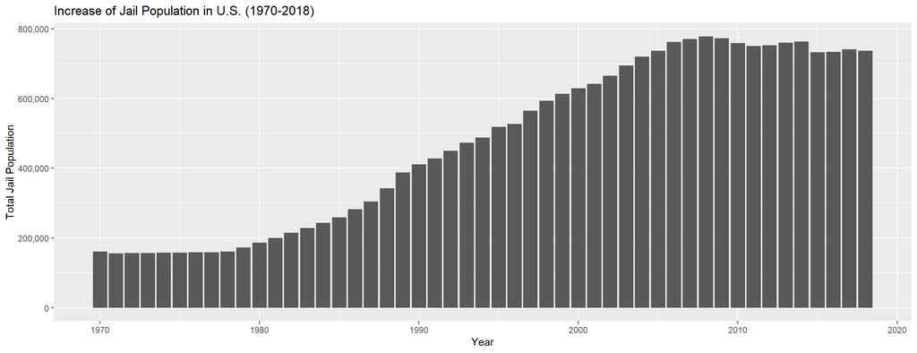

Figure 1: A bar chart showing the growth of the U.S. prison population for the years 1970-2018.

The first question I aimed to answer in my analysis was **“How has the total jail population in the United States changed throughout the years 1970 to 2018?”**.

What we see in the analysis graph is *a clear increase in the number of individuals held in U.S. jails throughout the years 1970 to 2018*. The number of jailed individuals seems to start increasing around 1979 and continues to increase thereafter until around 2008 when it peaks at nearly 800,000 individuals and begins to fall. Overall, the total jail population in the U.S. increased from around 170,000 inmates in 1970 to around 730,000 inmates in 2018.

## Growth of Prison Population by State

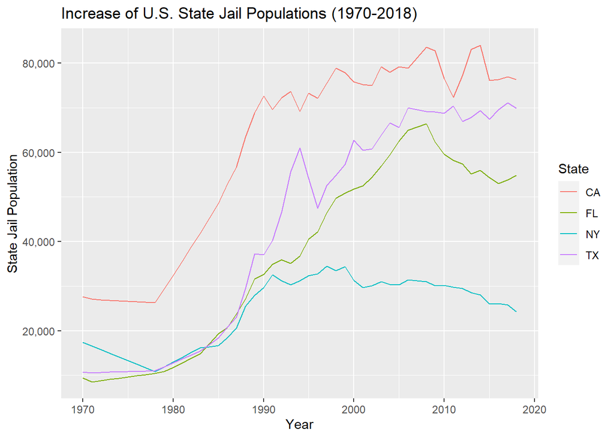

Figure 2: The chart shows the growth of the jail population in the U.S. States of California, Texas, Florida, and New York from 1970-2018.

The second question I wanted to answer in my analysis was **“How has the total jail population for the states of California, Florida, New York, and Texas changed throughout the years 1970 to 2018?”**.

From the analysis graph, we can see that *the state jail populations of California, Texas, Florida, and New York all increased during the time period of 1970 to 2018*. The four states California, Florida, Texas, and New York were chosen for analysis as they are the four most populous states, and should thus display the trend of jail population increase for the four states where the most people live.

In Florida, the increasing trend in state jail population began around 1977 and continued to increase until around 2008 when it peaked and began to fall. Throughout the time period, the Florida state jail population increased from around 10,000 inmates in 1970 to around 55,000 inmates in 2018.

In New York, the state jail population started in a decreasing pattern in 1970 and continued to fall until about 1977 when the population began to rise moderately. The state jail population continued to increase in New York until about 1999 when it plateaued and began to fall. Altogether, the state jail population of New York increased from about 18,000 inmates in 1970 to about 25,000 inmates in 2018.

Finally, in Texas, the state jail population started to increase in about 1977 and began to dramatically increase until around 1995, when it fell sharply. After falling sharply, the jail population began to rise again before beginning to level out at around 70,000 inmates in 2006. Over the time period, the Texas state jail population rose from about 10,000 inmates in 1970 to about 71,000 inmates in 2018.

## Black Representation in County Jail and Non-Inmate Populations

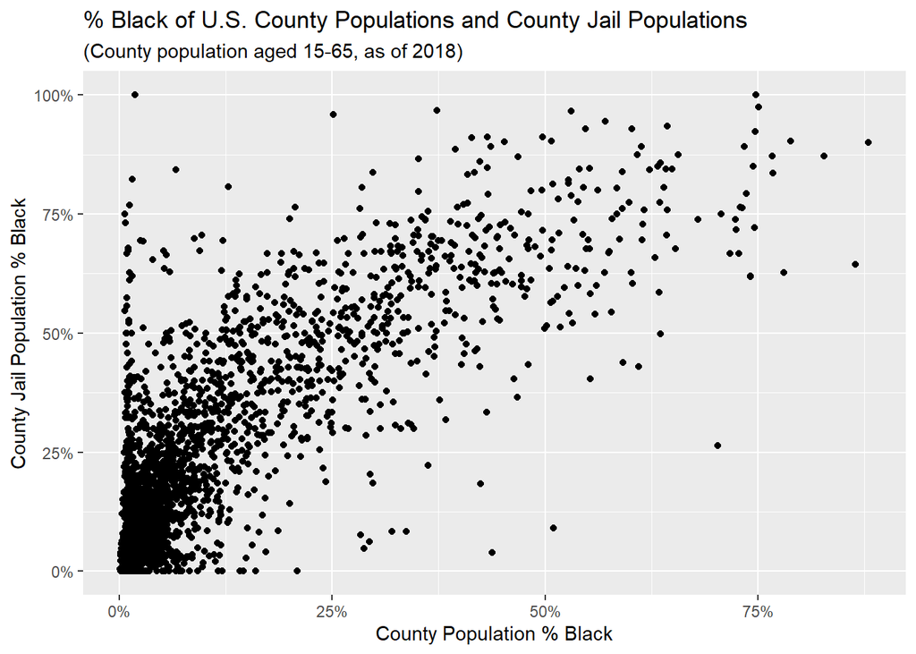

Figure 3: A scatterplot comparing the percent of a U.S. county jail population that is black, and the percent of a U.S. county population that is black (as of 2018).

The third question I wanted to explore in my analysis was **“How is the percentage of a county’s population aged 15 to 65 that is black related to the percentage of that same county’s jail population that is black?”**.

From my analysis graph, I determined that in 2018, *counties with populations that are more black generally tended to have more black jail populations*. That being said, the percentage of a county’s population that is black does not rise equivalently with the percentage of the county’s jail population that is black, and often a county’s jail population is much more black than its corresponding non-inmate population. Notably, the pattern is fairly variable and there are quite a few outlying data points with values outside of the general pattern.

Altogether, I think that what see in much of my analysis graph is mostly an overrepresentation of black individuals in county jail populations given each county’s percent black in non-inmate populations.

## Geographic Distribution of Black Representation in Jails

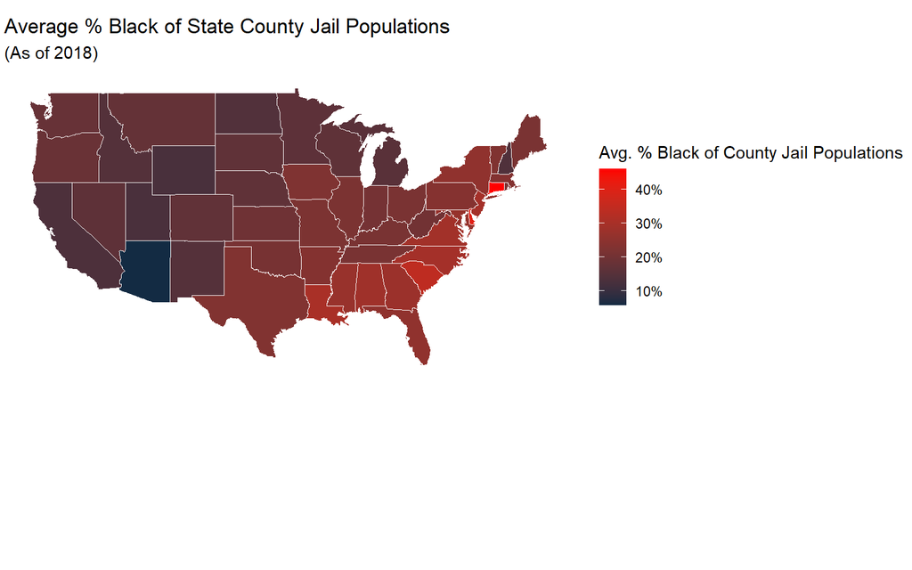

Figure 4: A map showing the contiguous United States, with each state colored from dark blue to bright red depending on the average proportion of that state’s county jail populations that are black (as of 2018).

The final question I sought to answer in my analysis was **“How does the average percentage of state’s county jail populations that are black vary geographically?”**.

From my analysis map, I determined that there is notable variation in the average percentage of state county jail populations that are black (as of 2018). Specifically, my analysis map shows that the *east coast states appear to have the highest average percentage black county jail populations* while the *mountain-west states have the lowest average percentage black county jail populations*. The state with the county jail populations that are on average most black is Connecticut, where county jail populations are on average over 40% black. In opposite, the state with the county jail populations that are on average least black is Arizona, where county jail populations are on average less than 10% percent black.